# Fighting diseases with predictive modeling

## Sensitivity (Recall), Specificity, Precision

The number of True and False predictions can be used to calculate other metrics of the performance of the models. The

**Sensitivity** AKA **Recall**: True Positive Rate, TruePositives/ (TruePositive + FalseNegatives). It indicates the percentage of Positives that are detected by the model

**Specificity**: True Negative Rate, TrueNegatives/ (TrueNegatives + FalsePositives). It indicates the percentage of Negatives identified by the model.

While the *sensitivity* informs us on how likely is that a positive case will be detected, it does not tell us how much confident we can be that a positive prediction will be indeed true. This is expressed by the *precision*.

**Precision**: TruePositives / (TruePositives+FalsePositives). It indicates how accurate are the positive predictions.

**F**: the harmonic mean of Precision and Recall.

We create the function `summary_td` that calculates those metrics and then `get_metrics` extract them from the different folds of the splitted dataset.

```r
summary_td <- function(x) {
      pr <- prSummary(x, lev = c("Yes", "No")) %>%
            t() %>%
            as.data.frame()
      tc <- twoClassSummary(x, lev = c("Yes", "No")) %>%
            t() %>%
            as.data.frame()
      bind_cols(pr, tc)
}

get_metrics <- function(mod) {

  modname <-  mod[["method"]]

  mod[["pred"]] %>%
  select(obs, pred, Yes, No, Resample) %>%
  # we split the dataframe in a list of dataframes
  split(., .$Resample) %>%
  # here we apply summary_td to each of the dataframes
  map_dfr(., summary_td, .id = "id") %>%
  mutate(model = !!modname ) %>%
  rename(Sensitivity = Sens, Specificity = Spec) %>%
  # reshape and summarize
  gather("metric","value", 2:(ncol(.)-1)) %>%
  group_by(model, metric) %>%
  summarize(mean = mean(value,na.rm =TRUE), sd = sd(value, na.rm =TRUE)) %>%
  ungroup()
}

metrics <- map_dfr(model_list, get_metrics)
glimpse(metrics)
```

```
Observations: 28
Variables: 4
$ model  <chr> "glmnet", "glmnet", "glmnet", "glmnet", "glmnet", "glmnet", "glmnet", "rpart", "rpart", "rpart", "rpart", "rpart", "rpart", "r…
$ metric <chr> "AUC", "F", "Precision", "Recall", "ROC", "Sensitivity", "Specificity", "AUC", "F", "Precision", "Recall", "ROC", "Sensitivity…
$ mean   <dbl> 0.12385818, 0.18717855, 0.11997301, 0.44701486, 0.71208738, 0.44701486, 0.83715032, 0.06202771, 0.07971497, 0.07337666, 0.0885…
$ sd     <dbl> 0.03399199, 0.05527510, 0.03646493, 0.13523005, 0.07976996, 0.13523005, 0.02862563, 0.01561911, 0.02440670, 0.02320167, 0.0290…
```

We plot the results.

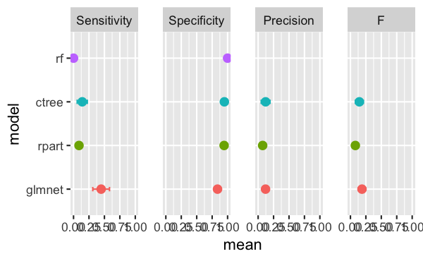

```r
metrics %>%
    filter(metric %in% c("Sensitivity", "Specificity", "Precision", "F")) %>%
    mutate(metric = factor(metric, levels = c("Sensitivity", "Specificity", "Precision", "F"))) %>%
    mutate(model = factor(model, levels = mod_names)) %>%
    ggplot(aes(y= mean, x = model, col = model)) +
    geom_point(size = 2.5) +
    geom_errorbar(aes(ymin = mean - sd, ymax =  mean + sd), width = 0.1) +
    scale_y_continuous(limits = c(0, 1)) +
    coord_flip() +
    facet_grid(. ~ metric) +
    theme(legend.position = "none",
          panel.spacing = unit(1.2, "lines"))
```

Again, **the glmnet model has the highest *sensitivity* and *F***. The tree-based models have very good *specificity* but poor *sensitivity* and *precision*. The performance of the Random Forest is even worse and, because no positive can be detected the *precision* and *F* cannot be calculated. **Overall, all the 4 models have poor performances**.

# Thresholds, ROC curves and Precision-Recall Curves

## Thresholds

Let’s take a closer look at the predictions of one of the model.

```r
glimpse(mod_ranger$pred)
```

```
Observations: 5,114
Variables: 7
$ mtry     <dbl> 157, 157, 157, 157, 157, 157, 157, 157, 157, 157, 157, 157, 157, 157, 157, 157, 157, 157, 157, 157, 157, 157, 157, 157, 157, 157, 157, 157, 157, 1…
$ pred     <fct> No, No, No, No, No, No, No, No, No, No, No, No, No, No, No, No, No, No, No, No, No, No, No, No, No, No, No, No, No, No, No, No, No, No, No, No, No…
$ obs      <fct> No, No, No, No, No, No, No, No, No, No, No, No, No, No, No, No, No, No, No, No, No, No, No, No, No, No, No, No, No, Yes, No, No, No, No, No, No, N…
$ Yes      <dbl> 0.046, 0.030, 0.048, 0.040, 0.032, 0.048, 0.052, 0.060, 0.082, 0.044, 0.046, 0.044, 0.040, 0.068, 0.074, 0.066, 0.034, 0.048, 0.044, 0.076, 0.024,…
$ No       <dbl> 0.954, 0.970, 0.952, 0.960, 0.968, 0.952, 0.948, 0.940, 0.918, 0.956, 0.954, 0.956, 0.960, 0.932, 0.926, 0.934, 0.966, 0.952, 0.956, 0.924, 0.976,…
$ rowIndex <int> 1623, 1655, 1657, 1636, 1628, 1632, 1634, 1627, 4555, 1643, 4763, 4768, 4793, 1612, 1624, 1626, 4482, 4492, 4547, 4548, 1635, 1513, 4762, 1517, 15…
$ Resample <chr> "Fold03", "Fold03", "Fold03", "Fold03", "Fold03", "Fold03", "Fold03", "Fold03", "Fold02", "Fold03", "Fold02", "Fold02", "Fold02", "Fold03", "Fold0…
```

You will notice that the model provides for each case a certain probability of *Yes* and of *No*. This probabilities are then used to generate the corresponding prediction, with values greater 0.5 cut-off flagged as *Yes* and smaller as *No*. However, there are scenarios in which **we might be willing to trade same precision and tolerate higher number of False Positives in exchange of an higher *sensitivity*** , for example when a False Negative and an error of the model might result in a big explosion in the real life out there (e.s. algorithm that identifies mines from sonar data).

To have a better idea of how the models will perform under those different conditions, we can simply **vary systematical the cut-of probability for assigning the prediction values (*Yes* or *No*) and then calculate the metrics** above indicated for each of the threshold. That is exactly the concept behind the ROC and Precision-Recall Curves.

## ROC curves

To calculate the data of the curves we will use the package `PRROC`. The [package](https://cran.r-project.org/web/packages/PRROC/vignettes/PRROC.pdf) has same very handy functions to calculate (and plot) ROC and Precision-Recall curves. We create our own function that extracts the data from multiple ``train` objects using the commands `PRROC::roc.curve` and `PRROC::pr_curve`, and then apply it to the same unpacked arguments (*quasiquoted*) with ``purrr:invoke_map```.

```r
get_rocpr <- function(mod, cv = "pr") {
  # cv = c("pr", "ROC")
  #

  lab <- mod[["pred"]][["obs"]] %>%
            recode(Yes = 1, No = 0)

  # labels go in weightclass https://academic.oup.com/bioinformatics/article/31/15/2595/187781

  # QuasiQuote https://adv-r.hadley.nz/quasiquotation.html
  fr <- list(scores.class0 = mod[["pred"]][["Yes"]], weights.class0 = lab, curve = TRUE)

  #invoke_map to apply 2 functions and same quoted arguments to the same data
  rocpr_data <- exec("invoke_map", list(pr.curve, roc.curve), !!!fr)

  # prec curve using the predition and observations of the model
  pr_data <-  tibble(Recall = rocpr_data[[1]]$curve[, 1],
                     Precision = rocpr_data[[1]]$curve[, 2],
                     Threshold = rocpr_data[[1]]$curve[, 3],
                     modname = mod[["method"]])


  roc_data <-   tibble(FPR = rocpr_data[[2]]$curve[, 1],
                       Sensitivity =rocpr_data[[2]]$curve[, 2],
                       Threshold = rocpr_data[[2]]$curve[, 3],
                       modname = mod[["method"]])

  if (cv ==  "pr")  return(pr_data)
  if (cv == "ROC") return(roc_data)
}
```

We obtain the data of the ROC curves applying our new created `get_rocpr` function to the list of models.

```r
data_roc <- map_dfr(model_list, get_rocpr, "ROC")

str(data_roc)
```

```
Classes ‘tbl_df’, ‘tbl’ and 'data.frame':   5332 obs. of  4 variables:
 $ FPR        : num  0 0.000205 0.000411 0.000616 0.000616 ...
 $ Sensitivity: num  0 0 0 0 0.00408 ...
 $ Threshold  : num  0.983 0.98 0.971 0.969 0.967 ...
 $ modname    : chr  "glmnet" "glmnet" "glmnet" "glmnet" ...
```

**A perfect model that is able to capture all the “Yes” and all the “No” will have Sensitivity = Specificity = 1**, and thus will generate a curve that passes through the upper left corner, continues parallel to the x-axes and reaches the top-right corner. On the other hand, a model that gives **random predictions will generate a curve that will lie in the vicinity of diagonal of the graph**. Of course we might have also a model that make predictions worse than random, in that case the curve will be to the right of the dotted line.

Before looking at the data, let’s slow down a little bit and spend few more worlds on the concept of threshold. At least initially, it is appealing to set the cut-off probability for assigning *Yes* or *No* equal to 0.5. What does that mean? It means that all the cases with probability of *Yes* less than 0.5 would be flagged as *No*, while all the other with probability more than 0.5 would be assigned to *Yes*. Our ``RandomForest` model generates probabilities that are all less than 0.5, and thus, with that threshold, it always predicts *No* (as we saw in the first table and graph). Because in ROC curves (and precision-recall curves) the threshold is systematically varied, **a model with *Yes* probabilities always less than 0.5** (as our RandomForest) **can still have good *sensitivity*, as long as there is a consistent probability differential between “Yes” and “No” observations**.

Here an example. We create 30 observation: the first 29 are “No” and the last one is “Yes”(`lab`). The probabilities generated by the model for the *Yes* cases are all less than 0.5 (`sc`), with the first 29 equal to 0.4 and the the last one, the Yes observation, equal to 0.41. We can automatically `plot`the data of class `PRROC`.

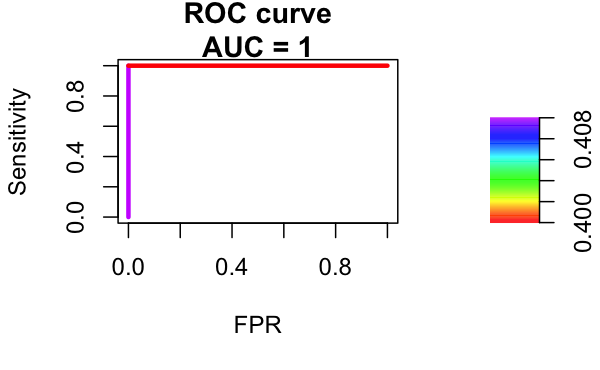

```r
# No is rappresented by 0, yes by 1
# observation are all No except the last one that is Yes
lab <- c(rep(0, 29), 1)

# probability is always < 0.5,
# but for the last case (the positive obs)
# is higher than the others (from 0.4 to 0.41)
sc <- c(rep(0.4, 29), 0.41)

roc <- roc.curve(scores.class0 = sc, weights.class0 = lab, curve = TRUE)
plot(roc)
```

The legend indicates the threshold at which *sensitivity* and *1-specificity* are calculated. When the threshold is set to 0.41, the model correctly recognizes the last observation as *Yes* and all the others as *No*. The predictions of the model are perfect, even if the probabilities for *Yes* are all minor than 0.5. Bearing this in mind we can look at our models.

Let’s plot the data of our models using `ggplot2`.

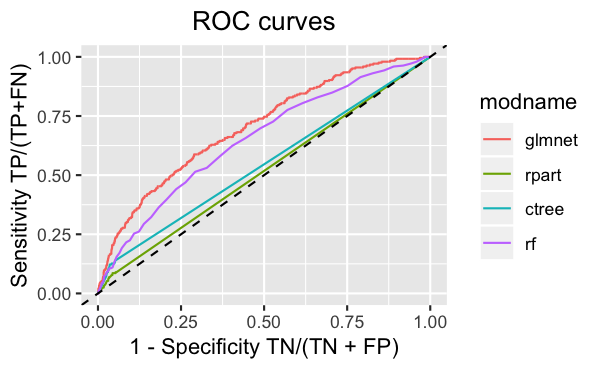

```r
data_roc  %>%
  mutate(modname = factor(modname, levels = mod_names)) %>%
  ggplot(aes(y = Sensitivity, x = FPR  , col = modname)) +
  geom_line() +
  geom_abline(slope = 1, intercept = 0, linetype = 2) +
  labs( y =  "Sensitivity TP/(TP+FN)",
        x = "1 - Specificity TN/(TN + FP)",
        title = "ROC curves") +
  theme(plot.title = element_text(hjust = 0.5))
```

The curve of the `glmnet` model is positioned more to the up-left of the graph than those of all the other models. The `RandomForest` ROC curve is immediately below the `glmnet`, followed by the ``rpart`and`ctree``` curves. These last two curves lie in close proximity of diagonal of the graph.

Therefore, if we consider these 2 metrics, **the `glmnet` has the best performance** and it is **followed by the `RandomForest`**. As in the example above, varying the probability threshold of the `RandomForest` allows us to capture more true positives and optimize the predictions of the model. On the other hand, the predictions of **`` rpart`` and ``ctree``` models remain only marginally better than chance**.

The best model (`glmnet`) detects 75% of the true positives (*sensitivity*=0.75), but has 50% chances of incorrectly identifying a negative (1 - Specificity = 0.5)…better than chance but still **far from perfect**.

## Precision-Recall Curve

A [good argument](https://www.ncbi.nlm.nih.gov/pmc/articles/PMC4349800/) has been made that the ROC curve can be misleading when dealing with very unbalanced classes. When the positive class is very small, the probability of making False Positive predictions increases. Because False Positives might still be a small percentage in comparison with True Negative, this different probability might only minimally affect the *specificity* of the model.

[Precision-Recall](https://classeval.wordpress.com/introduction/introduction-to-the-precision-recall-plot/) curves take that into account and plot the Precision (TruePositives / (TruePositives+FalsePositives)), instead of the *specificity*, as a function of the *sensitivity* (refereed as *recall*). In particular, the threshold probability is systematically varied, the 2 measures calculated and their maximal value plotted.

Let’s plot precision-recall curves of our models.

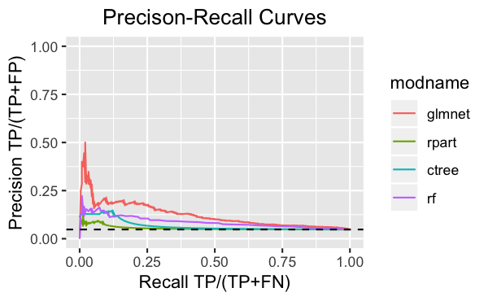

```r
data_pr <- map_dfr(model_list, get_rocpr, "pr")


data_pr  %>%
  mutate(modname = factor(modname, levels = mod_names)) %>%
  ggplot(aes(y = Precision, x = Recall, col = modname)) +
  geom_line() +
  geom_abline(slope = 0, intercept = 4.79/ 100, linetype = 2) +
  labs( y = "Precision TP/(TP+FP)",
        x = "Recall TP/(TP+FN)",
        title = "Precison-Recall Curves") +
  scale_y_continuous(limits = c(0,1)) +
  theme(plot.title = element_text(hjust = 0.5))
```

The `glmnet` model show the highest *precision*, followed by the `RandomForest`, the `ctree` and finally the `rpart` model. **Even our best model `glmnet`, has a maximal precision of 0.5 (only one over 2 positive predictions are true) at a *recall* of less than 10%.** This performance is better than pure chance but not as good as we would have hoped.

## The Area Under the Curve

We can summarize and compare the data of the ROC and precision-recall curves calculating the Area Under the Curve (AUC). The previously obtained`metrics` tibble contains the AUC of ROCs and precision-recall curves for each of the folds of the dataset. Let’s extract the data, summarize it and plot it.

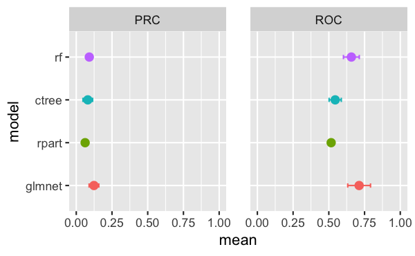

```r
metrics %>%
    filter(metric %in% c("AUC", "ROC")) %>%
    mutate(metric = fct_recode(metric, PRC = "AUC")) %>%
    mutate(model = factor(model, levels = mod_names)) %>%
    ggplot(aes(y= mean, x = model, col = model)) +
    geom_point(size = 2.5) +
    geom_errorbar(aes(ymin = mean - sd, ymax =  mean + sd), width = 0.1) +
    scale_y_continuous(limits = c(0, 1)) +
    coord_flip() +
    facet_grid(. ~ metric) +
    theme(legend.position = "none",
          panel.spacing = unit(1.2, "lines"))
```

The `glmnet` has the larger AUCs of ROCs and precision-recall curves, followed by the `RandomForest`. The 2 classification-tree models have the smallest AUCs, with values that approximate to those expected for random choices. **The `glmnet` model produces the most accurate predictions among the models, but its precision and sensitivity are still quite limited.**

# Highlights, judges score and result of the bout!

Let’s recap…

…so what is the outcome? Who won?

**The best model, ``glmnet`, give us a consistent advantage over pure change for predicting who in adulthood will have drug abuse problems. However, the perdiction as disappointingly very far from perfect.**

…so I would say that it’s…

…a DRAW.

The performance of the best model was very modest but **we had the opportunity to explore a lot of the fundamental concepts in machine learning and predictive analysis**, and overall that was the most important aim.

Moreover there are several things that can be done to increase the performance of the models: 1. The poor performance was at least partially due to **the severe class unbalance and the limited number of positive** (~4%: ~300). The public dataset that we analyzed is just a small portion of the data collected by ADD HEALTH. Analyzing the whole dataset would give us access to more positive cases and most likely increase the performance of the models. 2. **We have evaluated only an handful of hyperparameters**. With higher computational power we would be able to find better hyperparameters and probably increase the performance of the models. 3. This post was mainly focused on the use of `caret` for predictive modeling, and thus **not enough attention was placed on data exploration**. Know your data and you will be able to apply the most appropriate tools…

I hope that you liked the post. Next post will be on Shiny, Python and Reticulate or on PCA or something else. I still have to decide.